# Homework12

Nicole R Gorman

2024-05-04

- Load libraries

```r
library(dplyr)
library(ggplot2)
library(ggthemes)
library(patchwork)
```

**Components of a ggplot layer**

```
1. data frame: load data, create dataframe
2. variables mapped to aesthetics
3. geom = geometric used to draw the layer
4. stat = takes raw data and transforms it for useful plotting
5. position = adjustment prevents overplotting
```

```r
# May 4th demands use of built in starwars data frame
# read in/load data

data(starwars)
data <- data.frame(starwars)
```

```r
# explore the data just a bit to see what might be interesting to plot

str(data)
print(data)
table(data$height)
table(data$mass)
table(data$species)
```

- It looks like I need to create some categories and/or summary statistics of the data for plotting. I’ll try that in a bit. For now, I’ll take a quick look at a basic histogram looking at species.

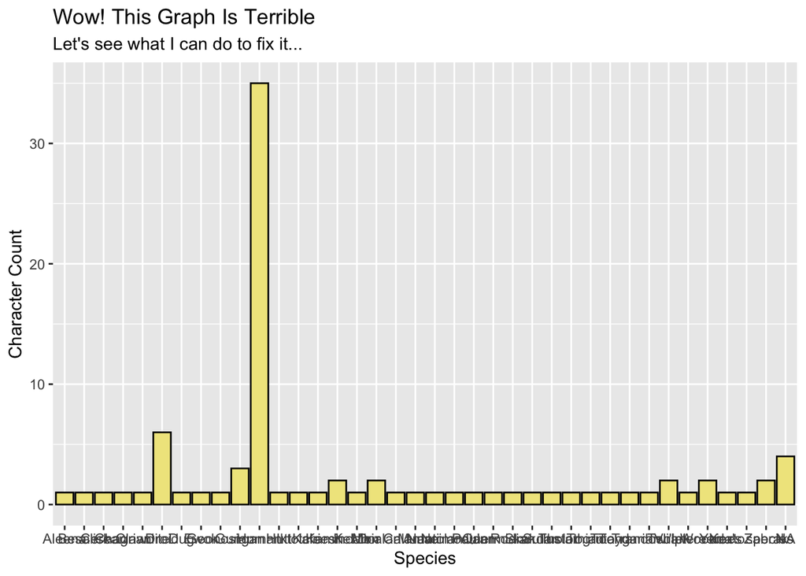

```r
p1 <- ggplot(data=data) +
      aes(x=species) +
      geom_bar(fill="khaki",color="black") +
      labs(title="Wow! This Graph Is Terrible",
          subtitle="Let's see what I can do to fix it...",
          x="Species",
          y="Character Count")
print(p1)
```

- I can use a summary statistic to make some sense of the data and also add some elements to the plot for a better visual summmary of the data. Add text annotations to a graph.

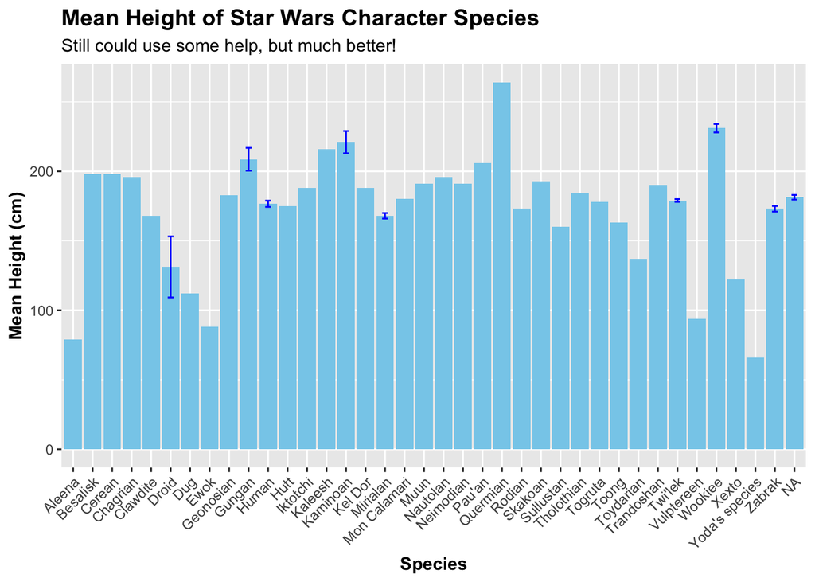

```r
# First I need to filter out missing values
starwars <- starwars %>% filter(!is.na(height))

# Now some summary stats
# Calculate the mean height standard error (insufficient data to find standard deviation) for each species
species_height <- starwars %>%
  group_by(species) %>%
  summarize(avg_height = mean(height, na.rm = TRUE),
            se_height = sd(height, na.rm = TRUE) / sqrt(n()))

# Sort the data by average height
species_height <- species_height[order(species_height$avg_height), ]

# Create the bar plot to visualize the relationship of height and species
p2 <- ggplot(species_height, aes(x = species, y = avg_height)) +
      geom_bar(stat = "identity", fill = "skyblue") +
      geom_errorbar(aes(ymin = avg_height - se_height, ymax = avg_height +
                    se_height), width = 0.3, color = "blue") +
      theme(axis.text.x = element_text(angle = 45, hjust = 1),
      plot.title = element_text(face = "bold", size = 14),
      axis.title.x = element_text(face = "bold", size = 11),
      axis.title.y = element_text(face = "bold", size = 11)) +
      labs(x = "Species", y = "Mean Height (cm)",
           title = "Mean Height of Star Wars Character Species",
           subtitle="Still could use some help, but much better!")
print(p2)
```

```r
# I tried to add a note at the bottom to point out interesting data, but I was not able to adjust the height appropriately so it would not interfere with the bar plot. It is commented out below.

# p1 + annotate("text", x = Inf, y = -Inf, hjust = 1, vjust = -.75,
#             label = "*Note relatively large error bar for droids may reflect phenotypic variability or small sample size", size = 3) +
#  theme(plot.margin = margin(b = -1.1, unit = "lines"))
```

- Compare the plots

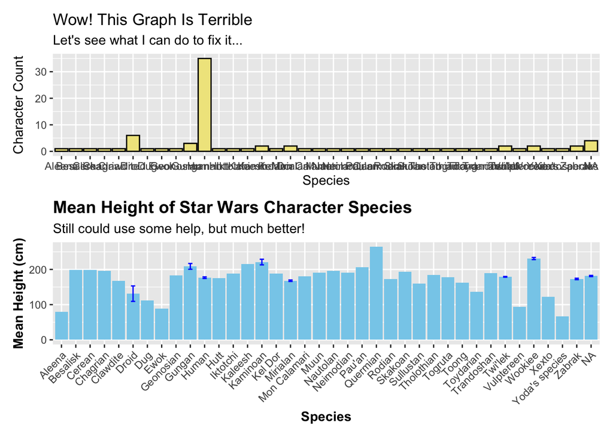

```r
# Place the plots vertically for easier comparison
  p1 + p2 + plot_layout(ncol=1)
```

- Explore another type of geom.
- OK…this is not a great figure, but could take some different parts and use them elsewhere

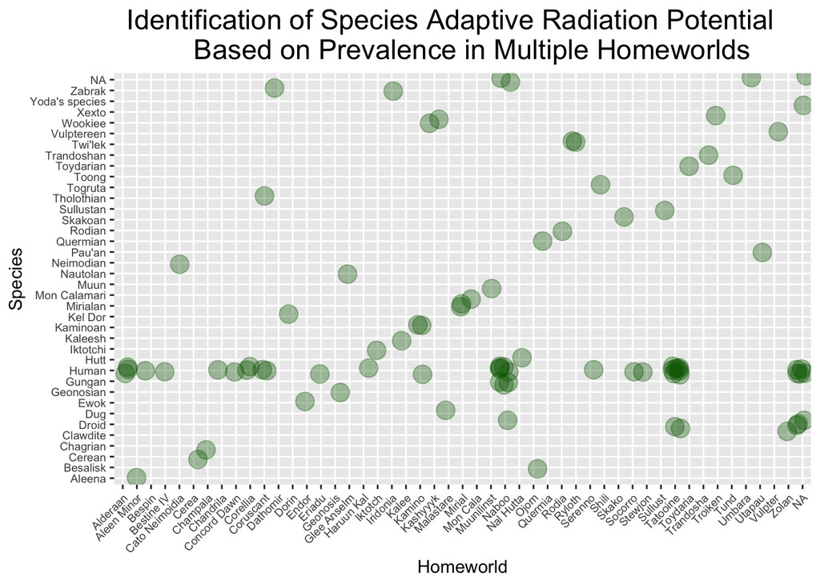

```r
# I have to convert 'homeworld' to numeric in order to show a trend line
data$homeworld_numeric <- as.numeric(factor(data$homeworld))

# Check the structure of the data
# str(data)

# Create a jitter dot plot
# Make dots transparent to visualize overlap/clustering

p3 <- ggplot(data = data, aes(x = homeworld, y = species, col=as.factor(sex))) +
      geom_jitter(alpha = 0.35, color = "darkgreen", size = 5) +
       labs(x = "Homeworld", y = "Species",
       title = "Identification of Species Adaptive Radiation Potential
       Based on Prevalence in Multiple Homeworlds") +
       theme(plot.title = element_text(size = 17,hjust = .3))
       # Change title size and center

# Rotate x-axis labels by 45 degrees
p3 <- p3 + theme(axis.text.x = element_text(angle = 45, hjust = 1, size = 7),
                 axis.text.y = element_text(size = 7))

plot(p3)
```

Change theme for a more engaging visual. Spacing between labels and title still needs to be adjusted, but theme improves visual impact.

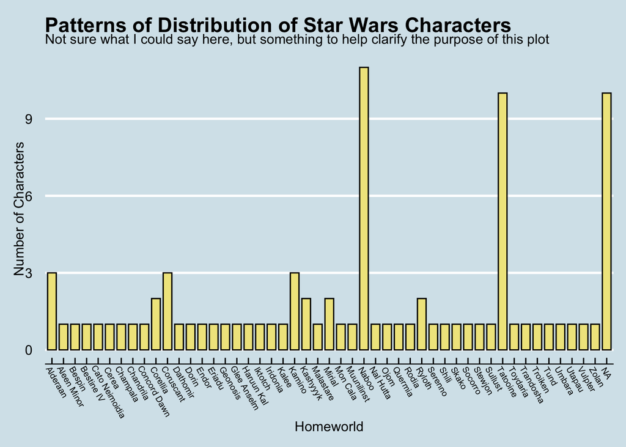

```r
# histogram
p4 <- ggplot(data=data) +
       aes(x=homeworld) +
       geom_bar (fill="khaki",color="black", width = 0.75 )

# many specialized themes
p4 + theme_economist() +
     theme(axis.text.x = element_text(angle = 300, hjust = .05, vjust = 1, size = 7, margin = margin(0, 0, 0, 0.05, "cm"))) +
     labs(title="Patterns of Distribution of Star Wars Characters",
         subtitle="Not sure what I could say here, but something to help clarify the purpose of this plot",
         x="Homeworld",
         y="Number of Characters")
```

- I tried to look at transportation, but couldn’t quite get my mind around what might be interesting to compare.

```r
# Get unique vehicles
unique_vehicles <- unique(unlist(starwars$vehicles))

# Create a summary data frame with homeworld and number of vehicles
homeworld_vehicles <- starwars %>%
  group_by(homeworld) %>%
  summarize(total_vehicles = sum(!is.na(vehicles)))

# None of the plots I tried showed anything worth looking at, but it seems like there should be something here.
#
#     labs(title = "The Relative Frequency of Motorized Transportation by Homeworld",
#     subtitle = "An extended subtitle that will print below the main title",
#            x = "Homeworld",
#            y = "Total Vehicles")

# Print the plot
# print(p5)
```

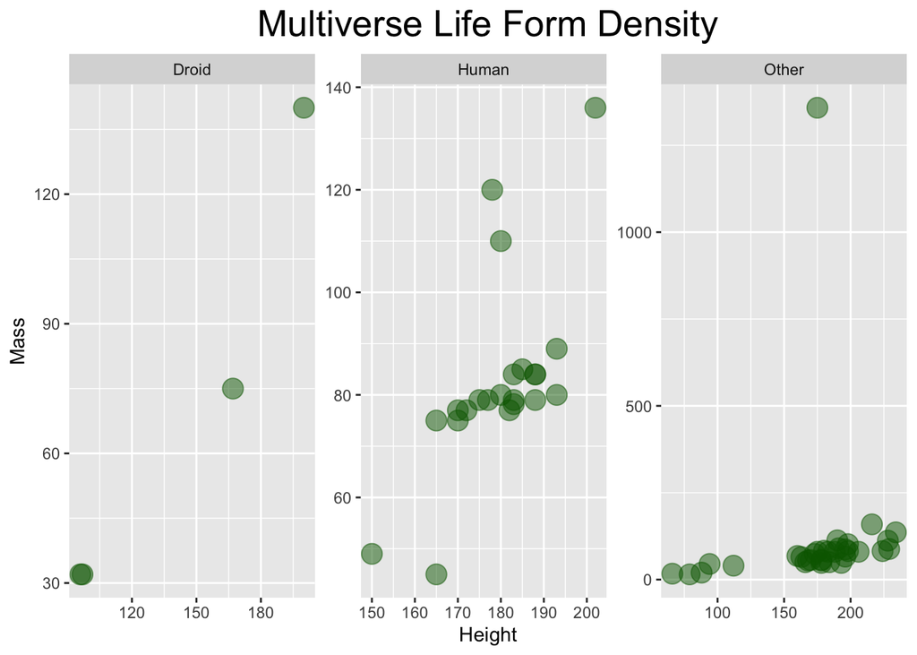

```r
# Filter out missing values
starwars <- starwars %>% filter(!is.na(height) & !is.na(mass))

# Not a great option because the other category need additional sorting criteria
# However, with additional sorting this could be a valuable tool for analysis

# Change "Unknown" to "Other life forms" in the species column
starwars <- starwars %>%
  mutate(species = case_when(
    species == "Unknown" ~ "Other Life Forms",
    TRUE ~ species
  ))

# Categorize species to try and identify a relationship between mass and height related to species
starwars <- starwars %>%
  mutate(species = ifelse(species == "", "Unknown", species)) %>%
  mutate(species_group = ifelse(species %in% c("Human", "Droid", "Other Life Forms"), species, "Other"))

# Create a facet plot
ggplot(starwars, aes(x = height, y = mass)) +
  geom_point(alpha = 0.5, color = "darkgreen", size =5) +
  facet_wrap(~ species_group, scales = "free") +
  labs(x = "Height", y = "Mass", title = "Multiverse Life Form Density") +
  theme(plot.title = element_text(size = 20, hjust = .5))
```